# Case study on Exponential Distribution

Aman Bhagat

21/04/2020

## Overview

In this report we aim to investigate the exponential distribution in R and compare it with the Central Limit Theorem. We have generated a thousand simulation with the mean of exponential distribution which is 1/lambda and standard deviation 1/lambda. For all the simulation we have set the lambda = 0.2. Basically we will be investigating the distribution of averages of 40 exponentials.

## Simulations

```r
set.seed(111)
lambda <- 0.2
n <- 40
sample.size <- 1000
sample.exponentials <- matrix(rexp(40000,0.2),sample.size,n)
sample.exponentials[1:5,1:5]
```

```
##           [,1]      [,2]       [,3]      [,4]     [,5]
## [1,] 0.9298128  1.364895 15.6583781 1.8972460 1.837269
## [2,] 2.2648112  1.458486  7.2567785 0.3423393 3.075893
## [3,] 5.8741760  2.060109  0.5767754 5.6395793 1.760570
## [4,] 0.1492383  6.476079  0.5697798 1.9120896 2.322804
## [5,] 6.0190002 11.305384  0.7265282 1.3835789 7.021825
```

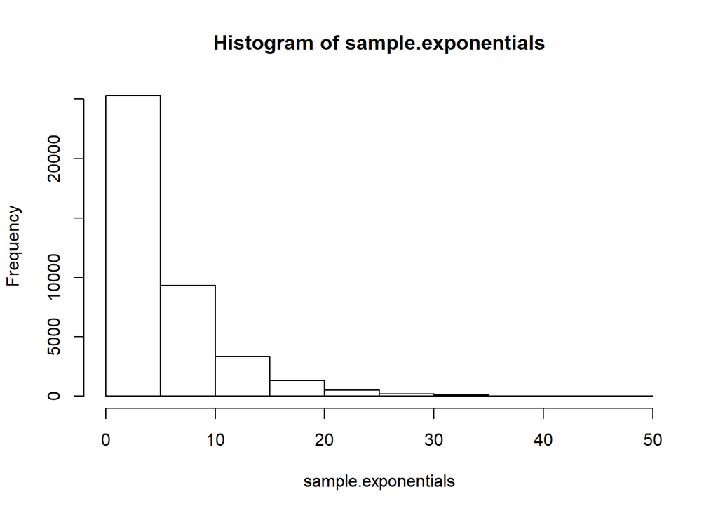

```r
hist(sample.exponentials)
```

*Here we can see few simulated exponentials and the histogram of sample exponentials which follows exponential distribution. The total number of rows is 1000 and the total number of columns in a row is 40*

Now we will find the average of 40 exponentials that is we will take average of each row and then investigate further.

```r
sample.mean <- apply(sample.exponentials, 1, mean)
```

Now the sample mean from the average of each 40 averaged exponential is

```r
averaged.mean <- mean(sample.mean)
averaged.mean
```

```
## [1] 5.02562
```

While the mean from the original simulated can be calculated from the lambda which was 0.2, which gives us:

```r
theo.mean <- 1/lambda
theo.mean
```

```
## [1] 5
```

If we compare the simulated mean (i.e. 5) with the averaged mean(i.e. 5.03) which is very close to each other.